# XCO2 - Aquisição e Processamento de dados

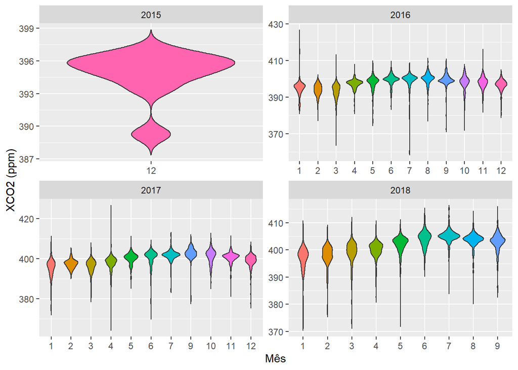

```r
oco_2 %>%
  mutate(ano_mes = paste0(ano,mês)) %>%
  group_by(ano,mês) %>%
  ggplot(aes(y=xco2_obs,x=as.factor(mês),
             fill=as.factor(mês)))+
  geom_violin(trim = FALSE) +
  theme(legend.position = "none")+
  facet_wrap(~ano,scales = "free")+
  labs(x="Mês",y="XCO2 (ppm)")
```

Agora podemos ver a emissão de $CO_2$ ao longo do tempo para esses dados.

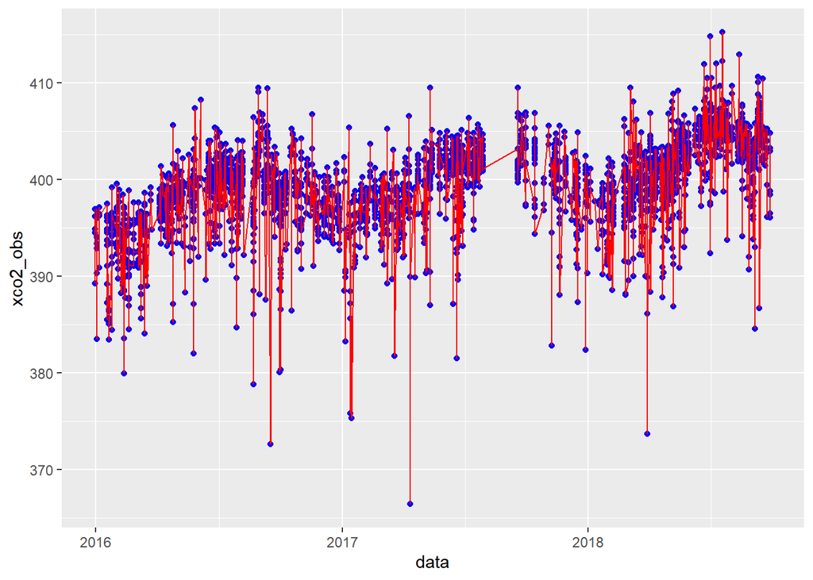

```r
oco_2 %>%
  filter(point_in_pol) %>%
  ggplot(aes(x=data,y=xco2_obs)) +
  geom_point(color="blue") +
  geom_line(color="red")
```

Agora devemos retirar a tendência ao longo do tempo, para isso, dentro do período específico, faremos a retirada por meio de um ajuste linear:

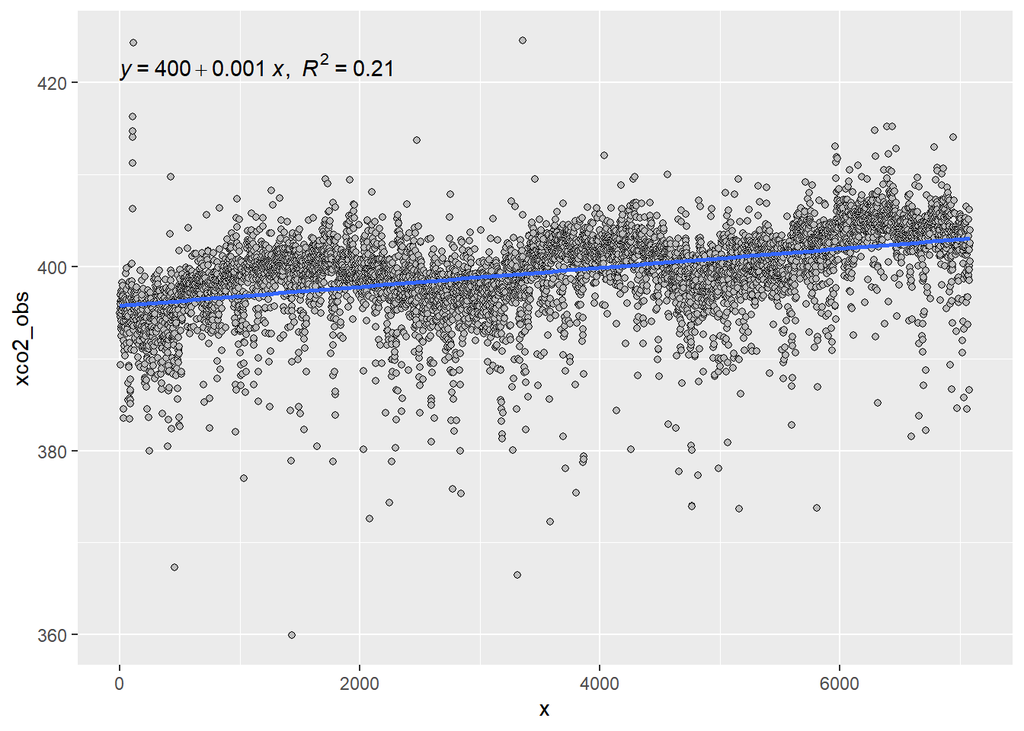

```r
oco_2 %>%
  mutate(x= 1:nrow(oco_2)) %>%
  ggplot(aes(x=x,y=xco2_obs)) +
  geom_point(shape=21,color="black",fill="gray") +
  geom_smooth(method = "lm") +
  stat_regline_equation(aes(
  label =  paste(..eq.label.., ..rr.label.., sep = "*plain(\",\")~~")))
```

Extrair os coeficientes $a$ e $b$ da análise de regressão linear ($y = a + bX$.

```r
d_aux<-oco_2 %>%
  mutate(x= 1:nrow(oco_2)) %>%
  filter(point_in_pol) %>%
  select(x,xco2_obs)
mod <- lm(d_aux$xco2_obs~d_aux$x)
summary.lm(mod)
```

```
##
## Call:
## lm(formula = d_aux$xco2_obs ~ d_aux$x)
##
## Residuals:
##     Min      1Q  Median      3Q     Max
## -32.953  -1.829   0.600   2.371  12.605
##
## Coefficients:
##              Estimate Std. Error t value Pr(>|t|)
## (Intercept) 3.960e+02  1.336e-01 2963.00   <2e-16 ***
## d_aux$x     1.039e-03  3.261e-05   31.85   <2e-16 ***
## ---
## Signif. codes:  0 '***' 0.001 '**' 0.01 '*' 0.05 '.' 0.1 ' ' 1
##
## Residual standard error: 3.799 on 3305 degrees of freedom
## Multiple R-squared:  0.2349, Adjusted R-squared:  0.2346
## F-statistic:  1015 on 1 and 3305 DF,  p-value: < 2.2e-16
```

```r
a<-mod$coefficients[1]
b<-mod$coefficients[2]
```

Criando a variável `xco2_est` a partir da retirada da tendência

```r
oco_2 <- oco_2 %>%
  mutate(
    xco2_est = a + b * as.numeric(data),
    delta = xco2_est - xco2_obs,
    XCO2 = (a-delta) - (mean(xco2_obs) - a)
  ) %>%
  glimpse()
```

```
## Rows: 7,083
## Columns: 13
## $ longitude              <dbl> -53.08868, -52.59869, -52.59869, -52.35370, ...
## $ latitude               <dbl> -19.34405, -21.84135, -21.59162, -22.84027, ...
## $ time..YYYYMMDDHHMMSS.  <dbl> 2.015123e+13, 2.015123e+13, 2.015123e+13, 2....
## $ xco2..Moles.Mole...1.. <dbl> 0.000394907, 0.000389277, 0.000396174, 0.000...
## $ xco2_obs               <dbl> 394.907, 389.277, 396.174, 396.014, 396.949,...
## $ ano                    <dbl> 2015, 2015, 2015, 2015, 2015, 2015, 2015, 20...
## $ mês                    <dbl> 12, 12, 12, 12, 12, 12, 12, 12, 12, 1, 1, 1,...
## $ dia                    <dbl> 31, 31, 31, 31, 31, 31, 31, 31, 31, 16, 16, ...
## $ data                   <date> 2015-12-31, 2015-12-31, 2015-12-31, 2015-12...
## $ point_in_pol           <lgl> TRUE, TRUE, TRUE, FALSE, TRUE, TRUE, FALSE, ...
## $ xco2_est               <dbl> 413.4035, 413.4035, 413.4035, 413.4035, 413....
## $ delta                  <dbl> 18.49653, 24.12653, 17.22953, 17.38953, 16.4...
## $ XCO2                   <dbl> 374.0009, 368.3709, 375.2679, 375.1079, 376....
```

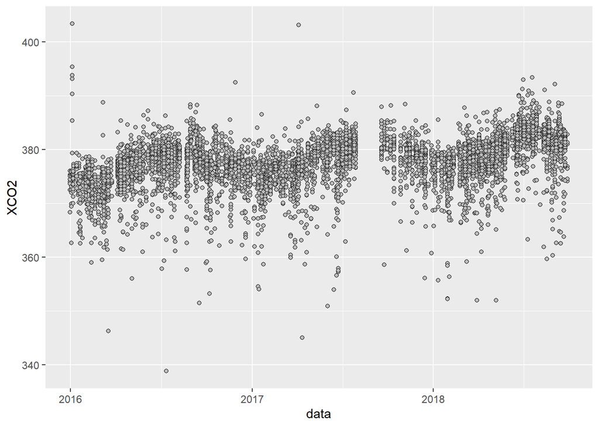

```r
oco_2 %>%
  # filter(point_in_pol) %>%
  ggplot(aes(x=data,y=XCO2)) +
  geom_point(shape=21,color="black",fill="gray")
```

Buscando os dados de duas regiões

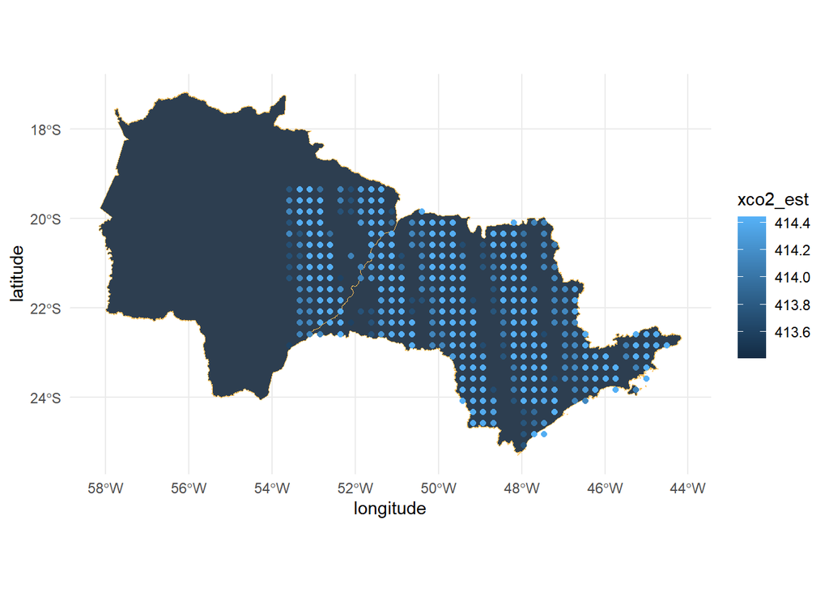

```r
# Criando o filtro
oco_2 <- oco_2 %>%
  mutate(
    point_in_pol_sp_ms = as.logical(point.in.polygon(point.x = longitude,
                                    point.y = latitude,
                                    pol.x = pol_sp[,1],
                                    pol.y = pol_sp[,2])
                              |

                                point.in.polygon(point.x = longitude,
                                    point.y = latitude,
                                    pol.x = pol_ms[,1],
                                    pol.y = pol_ms[,2]))
  )

# Plotando os dados
ggplot(sp) +
  geom_sf(fill="#2D3E50", color="#FEBF57",
          size=.15, show.legend = FALSE)+
  geom_sf(data=ms,fill="#2D3E50", color="#FEBF57",
          size=.15, show.legend = FALSE)+
  theme_minimal() +
    geom_point(data=oco_2 %>% filter(point_in_pol_sp_ms),
             aes(x=longitude,y=latitude,color=xco2_est))
```

```r
oco_2 <- oco_2 %>%
  mutate(
    point_in_pol_2 = as.logical(point.in.polygon(point.x = longitude,
                                    point.y = latitude,
                                    pol.x = pol_ms[,1],
                                    pol.y = pol_ms[,2]))
  ) %>%
  glimpse()
```

```
## Rows: 7,083
## Columns: 15
## $ longitude              <dbl> -53.08868, -52.59869, -52.59869, -52.35370, ...
## $ latitude               <dbl> -19.34405, -21.84135, -21.59162, -22.84027, ...
## $ time..YYYYMMDDHHMMSS.  <dbl> 2.015123e+13, 2.015123e+13, 2.015123e+13, 2....
## $ xco2..Moles.Mole...1.. <dbl> 0.000394907, 0.000389277, 0.000396174, 0.000...
## $ xco2_obs               <dbl> 394.907, 389.277, 396.174, 396.014, 396.949,...
## $ ano                    <dbl> 2015, 2015, 2015, 2015, 2015, 2015, 2015, 20...
## $ mês                    <dbl> 12, 12, 12, 12, 12, 12, 12, 12, 12, 1, 1, 1,...
## $ dia                    <dbl> 31, 31, 31, 31, 31, 31, 31, 31, 31, 16, 16, ...
## $ data                   <date> 2015-12-31, 2015-12-31, 2015-12-31, 2015-12...
## $ point_in_pol           <lgl> TRUE, TRUE, TRUE, FALSE, TRUE, TRUE, FALSE, ...
## $ xco2_est               <dbl> 413.4035, 413.4035, 413.4035, 413.4035, 413....
## $ delta                  <dbl> 18.49653, 24.12653, 17.22953, 17.38953, 16.4...
## $ XCO2                   <dbl> 374.0009, 368.3709, 375.2679, 375.1079, 376....
## $ point_in_pol_sp_ms     <lgl> TRUE, TRUE, TRUE, FALSE, TRUE, TRUE, FALSE, ...
## $ point_in_pol_2         <lgl> TRUE, TRUE, TRUE, FALSE, FALSE, FALSE, FALSE...
```

Vamos refazer o mapa anterior com os dados dentro do polígono.

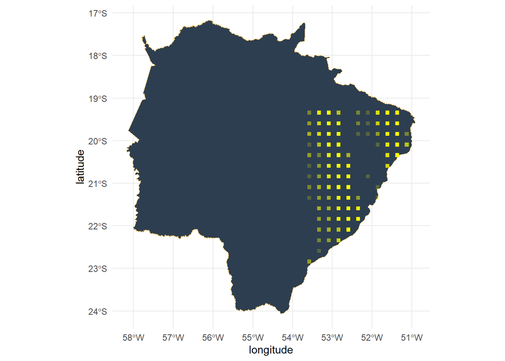

```r
ggplot(ms) +
  geom_sf(fill="#2D3E50", color="#FEBF57",
          size=.15, show.legend = FALSE)+
  geom_sf(data=ms,fill="#2D3E50", color="#FEBF57",
          size=.15, show.legend = FALSE)+
  theme_minimal() +
    geom_point(data=oco_2 %>% filter(point_in_pol_2),
             aes(x=longitude,y=latitude),shape=15,col="yellow",alpha=0.2)
```